# Onderzoek naar de correlatie tussen leeftijd en schoenmaat

Jort, Mathijs, Adib, Bram

24/4/2023

### Onderzoeksvraag

Is er een verschil in schoenmaat tussen verschillende sexe

### hypothese

Er is bij de mens een sexe-verschil in schoenmaat

### nulhypothese

er is geen verschil in schoenmaat tussen de sexe

### experiment

Ons plan om ons onderzoeksvraag te beantwoorden van is er een verschil in schoenmaat bij mensen met een sexeverschil. Dit beantwoorden we door 20 mannen en 20 vrouwen te vragen wat hun schoenmaat is.

### Benodigheden

1. stem
2. vraag

### Data verzamelen

we Zoeken samen met ons groepje van de klas, in of rond het schoolgebouw medestudenten. we Vragen beleefd of ze willen participeren in een klein wetenschappelijk onderzoekje voor school waarbij de maten van de schoen en leeftijd zullen worden opgenomen. Is het antwoord nee, dan groet je vriendelijk en zoek je verder. Is het antwoord ja, dan vraag je of de proefpersoon zijn schoenmaat en leeftijd wil vertellen. Deze leggen we vast in onze spreadsheet, samen met een laborant-ID van de proefpersoon. Ten slotte vraag je aan de proefpersoon zijn/haar sexe en legt deze vast. Wil de proefpersoon deze niet geven, of is die nonbinair, dan leggen we dit vast als “anders/onbekend”. Bedank de proefpersoon voor deelname. Wissel de metingen af tussen de verschillende studenten in jouw groepje.

We gaan door totdat we ten minste 40 proefpersonen de gegevens zijn verzameld.

### Data-analyse en interpretatie

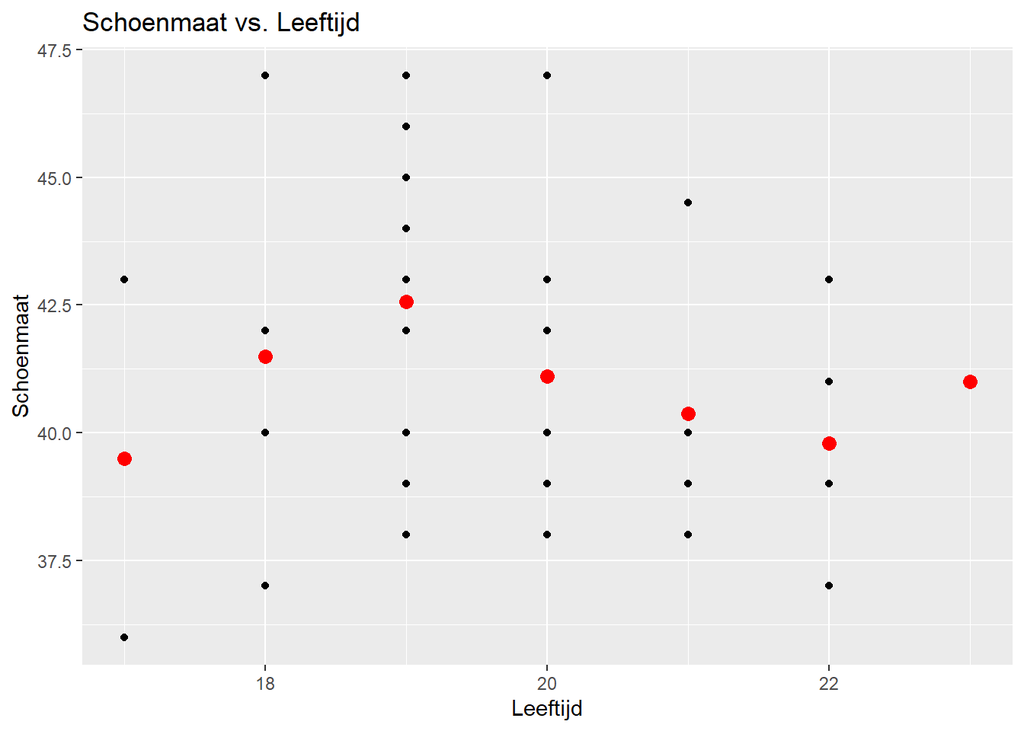

[figure not shown]

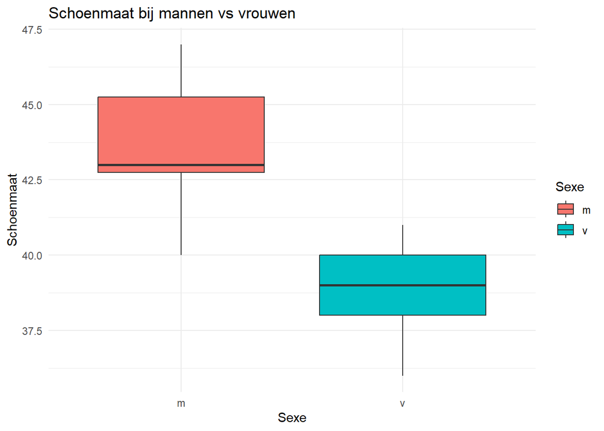

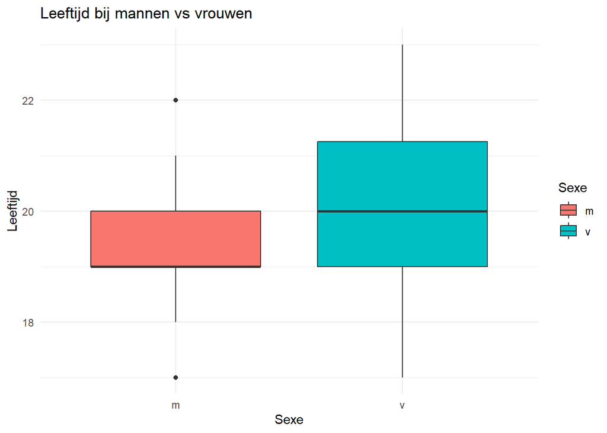

```
##
##  Shapiro-Wilk normality test
##
## data:  biometric_data$Schoenmaat
## W = 0.95243, p-value = 0.09193
```

```
##
##  Shapiro-Wilk normality test
##
## data:  biometric_data$Leeftijd
## W = 0.93296, p-value = 0.02015
```

```
##
##  Welch Two Sample t-test
##
## data:  female_ratios and male_ratios
## t = -9.4113, df = 33.052, p-value = 7.123e-11
## alternative hypothesis: true difference in means is not equal to 0
## 95 percent confidence interval:
##  -6.050425 -3.899575
## sample estimates:
## mean of x mean of y
##    38.850    43.825
```

```
##
##  Wilcoxon rank sum test with continuity correction
##
## data:  Schoenmaat by Sexe
## W = 396, p-value = 1.02e-07
## alternative hypothesis: true location shift is not equal to 0
```

## reflectie

Het verschil tussen mannen en vrouwen met de schoenmaat is wel sitgnificant verschillend. Mannen hebben gemiddeld een schoenmaat van 4-5 meer dan vrouwen. De leeftijd is niet significant tot de schoenmaat, want er is geen duidelijk verschil in grootte van schoenmaat bij mensen die ouder zijn dan de rest. we zouden de verschil in schoenmaat kunnen verklaren door het feit dat mannen andere hormonen hebben dan vrouwen. Het hormoon wat zorgt voor onder andere grotere voeten is testosteron. Dit hormoon zorgt voor betere groei en ontwikkeling van de botten, en dus ook grotere voeten.

De P bij leeftijd is significant verschillend, dit komt omdat bij de mannen we de eerstejaars groep voor het grootste gedeelte hebben gevraagd. Daarna hebben we een willekeurige groep gevraagd in de kantine die uit verschillende jaren kunnen komen, waardoor de P significant verschilt van de normale verdeling.

De data van ons onderzoek zouden we veranderen doordat leeftijd geen relatie heeft in schoenmaat, dus daardoor zouden wij dit dit protocol aanpassen als we het nog een keer gaan doen en leeftijd vervangen met de lengte van de persoon in centimeters.

Vervolgens hebben we deze dataset geanalyseerd en gevisualiseerd met behulp van R.

Een van de visualisaties die we hebben gemaakt was een scatterplot van schoenmaat tegen leeftijd, waarbij we ook de gemiddelde schoenmaat per leeftijdsgroep hebben weergegeven. Hieruit bleek dat er geen duidelijk verband bestaat tussen schoenmaat en leeftijd.

Een andere visualisatie was een histogram van schoenmaten, opgesplitst per geslacht. Hieruit bleek dat mannen over het algemeen grotere schoenmaten hebben dan vrouwen.

Om dit verder te onderzoeken hebben we ook boxplots gemaakt van de schoenmaten en leeftijden, opgesplitst per geslacht. Hieruit bleek dat mannen inderdaad over het algemeen grotere schoenmaten hebben dan vrouwen, maar dat er geen duidelijk verschil is in leeftijd tussen mannen en vrouwen.